# Creación de API Mediante FLASK

Trabajo realizado por:

- *Sergio Ranz Casado*
- *Marcos Medina Cogolludo*

## CREACIÓN DE API MEDIANTE FLASK

Para realizar la creación de la api, usaremos el mejor modelo obtenido en la [`práctica 1`](http://localhost:8888/notebooks/Desktop/CUNEF/Practica-2-ML/accidentes_api/lightgbm.ipynb) del curso. En él, guardamos el modelo usando la libreria [`pickle`](https://machinelearningmastery.com/save-load-machine-learning-models-python-scikit-learn/). Podemos elegir entre diferentes tipos de formatos de cómo guardar el modelo nosotros escogemos el [`.pkl`]

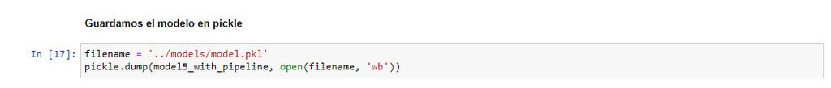

Como nuestro modelo ya incluye tratamiento de datos mediante el uso de pipelines. No vamos a necesitar transformar nada en nuestra api. Así pues, comenzamos construyendo la api en un formato **`.py`** Para ello haremos uso de **Visual Studio Code**.

#### Pasos a seguir para la creación de la API:

El primer paso para comenzar a construir nuestra API es la instalacción de [`Flask`](https://www.tutorialspoint.com/flask/flask_overview.htm). Flask es un marco de desarrollo de servicios web en python y otros lenguajes de programación, es uno de los mas utilizados por cientificos de datos debido a su interfaz ligera, su configuración minima y que se puede controlar desde el propio codigo python.

Nos descargamos la libreria flask haciendo uso de conda, en el entorno seleccionado para la práctica.

Para comenzar, elaboramos una estructura sencilla para ver su simple funcionamiento:

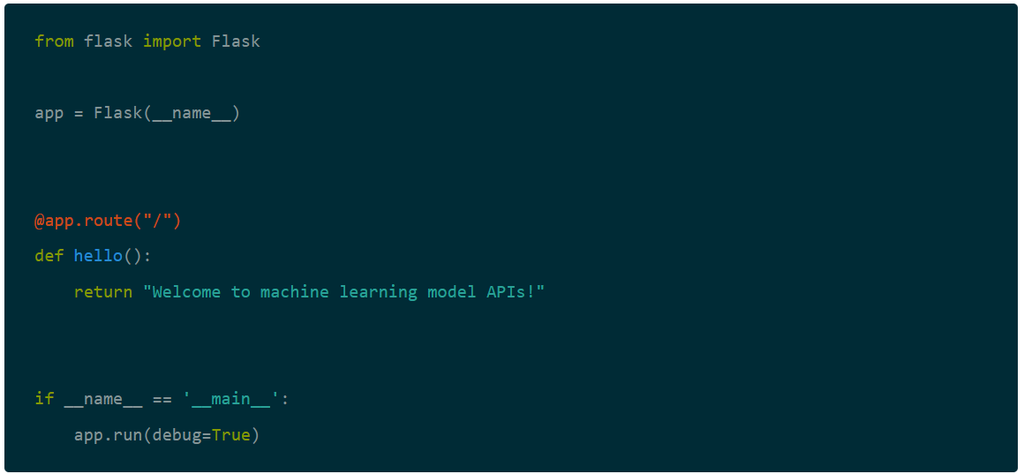

Una vez tenemos el código, guardamos el archivo con el nombre de **api.py** este es ejecutado en la terminal (cmd), con el comando `python (o en su defecto python3) api.py`. Una vez hallamos ejecutado, podemos irnos a la pestaña de Google Chrome donde introducimos la dirección que hemos obtenido como respuesta a la ejecución. Como resultado obtendremos esto:

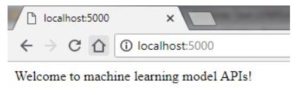

Una vez que tenemos en mente la ejecución sencilla de lo que pretendemos hacer. Es hora de comenzar a diseñar la api para nuestro modelo de machine learning.

1.) Cargamos librerias:

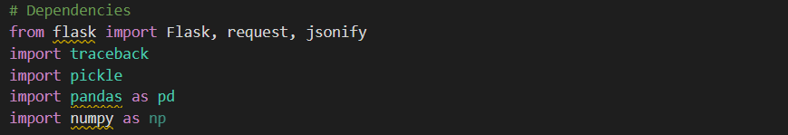

Resaltamos el uso de la libreria **[`traceback`](https://rico-schmidt.name/pymotw-3/traceback/index.html)** que proporciona una interfaz estándar para extraer, formatear e imprimir rastros de pila de programas Python.

2.1.) Continuando con la estructura que hemos probado anteriormente, definimos la manera en la que activamos la API. En este caso, sera mediante la introducción de la palabra `/predict`al final de la URL que obtenemos.

Definimos tambien dos tipos de solicitud:

- GET: Es el tipo más simple de método de solicitud HTTP; La que usan los navegadores cada vez que hace clic en un enlace o escribe una URL en la barra de direcciones. Indica al servidor que transmita los datos identificados por la URL al cliente. Los datos nunca deben ser modificados en el lado del servidor como resultado de una solicitud GET. En este sentido, una petición GET es de sólo lectura, pero por supuesto, una vez que el cliente recibe los datos, es libre de hacer cualquier operación con ella por su cuenta, por ejemplo, formatearla para su visualización.
- POST: Se utiliza cuando el procesamiento que desea que suceda en el servidor debe repetirse, si la solicitud POST se repite (es decir, no son idempotent, más de esto a continuación). Además, las solicitudes POST deben causar el procesamiento del cuerpo de la solicitud como un subordinado de la URL que está publicando.

  Podeis ver mas métodos de solicitud [`aqui`](https://code.tutsplus.com/es/tutorials/a-beginners-guide-to-http-and-rest--net-16340)

El último paso que vemos en esta imagen es la definición de la predicción. Como nuestro modelo ya tiene pipelines, no hará falta realizar un preprocesado de la petición (`request`). EL único proceso que realizamos es la transformación de la petición en un dataframe que posteriormente predecimos con nuestro modelo cargado (*lo cargaremos en las próximas lineas de codigo*). Programamos la respuesta de la API que será la predicción (0 o 1) que nos ha mostrado el modelo.

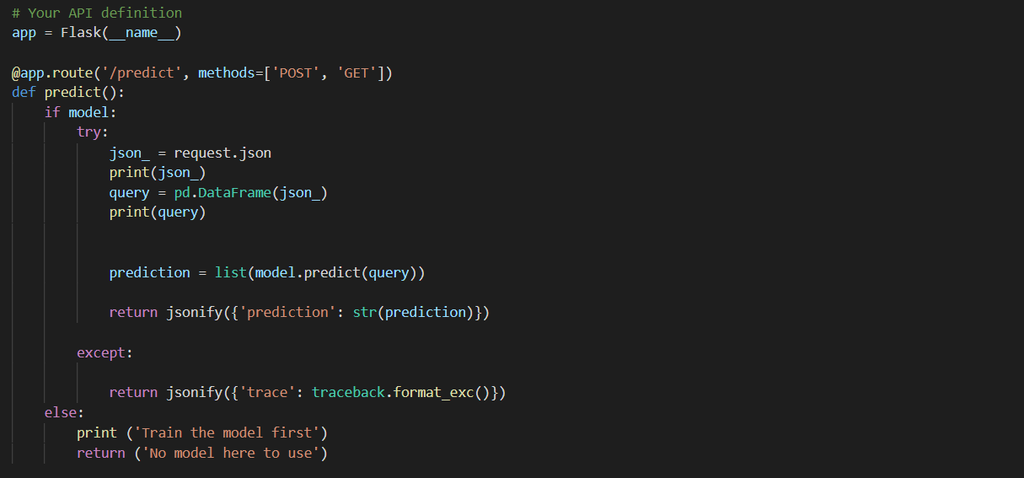

2.2.) En la segunda parte de la API definimos los puestos de salida y cargamos el modelo.

Por último, definimos el app.run, indicandole el puerto definido anteriormente, el host (en este caso el local 0.0.0.0).

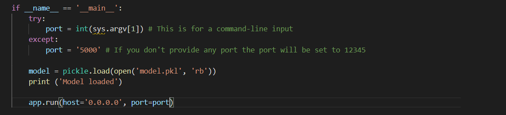

3.) Ejecutamos la API mediante la terminal CMD (COMMAND PROMPT) de Visual Studio Code.

- Primero activamos el enviroment necesario, en este caso, el creado para la práctica 1. `Conda activate practica_final`
- Segundo, introducimos el comando: `cd/ruta/donde/esta/la/api` para ir hacia el lugar indicado.
- Tercero, ejecutamos el comando: python `app.py`para activar la API.

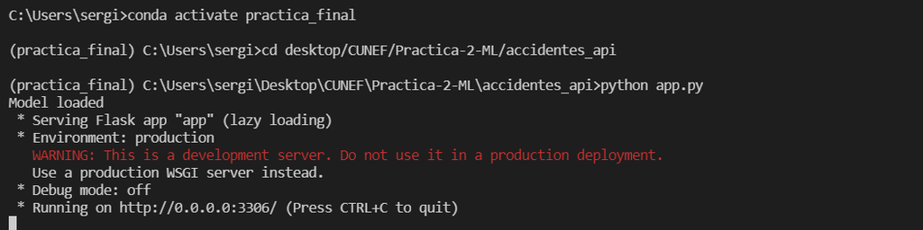

4.) Una vez tenemos la respuesta de la ejecución. En este caso nos muestra una URL `http://0.0.0.0:3306/`. Procedemos a introducir en [`POSTMAN`](https://www.postman.com/).

En postman, primero vamos a `MyWorkSpace`, señalamos `NUEVA API`. Una vez dentro nos saldrá una pantalla como la que mostramos aqui abajo.

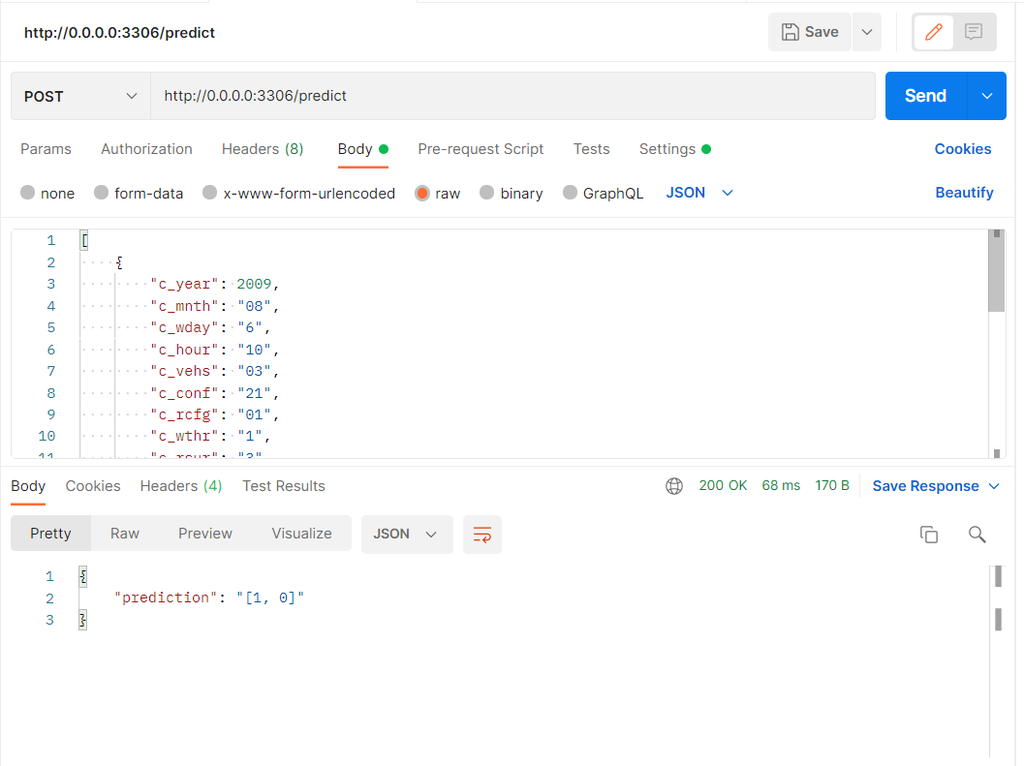

Para comprobar que nuestra API funcionaba correctamente, tambien hemos introducido dos `print()`. Que nos muestra las peticiones que hemos realizado, así que, para ver la petición que ha recibido nuestra API solo tendremos que irnos a la terminal del Visual Studio:

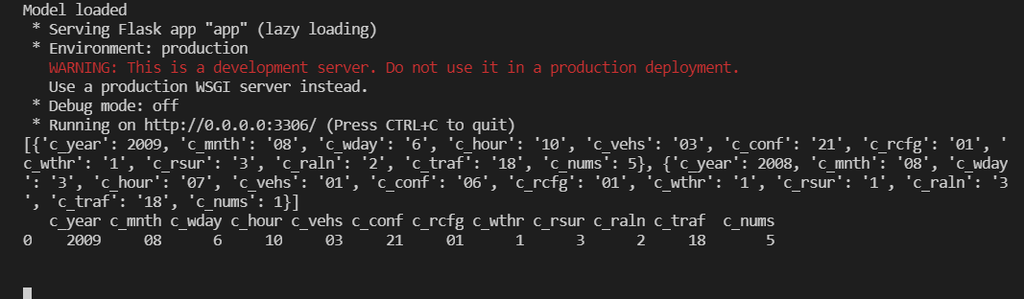

Podemos ver como correctamente ha recibido el requerimiento, y ha ejecutado el modelo. Ya tenemos nuestra API lista y en funcionamiento.

#### ENLACES DE INTERÉS:

- [`Turning Machine Learning Models into APIs in Python`](https://www.datacamp.com/community/tutorials/machine-learning-models-api-python)
- [`POSTMAN`](https://www.postman.com/)
- [`How to Easily Deploy Machine Learning Models Using Flask`](https://towardsdatascience.com/how-to-easily-deploy-machine-learning-models-using-flask-b95af8fe34d4)
- [`How to Build A Machine Learning API Using Flask`](https://towardsdatascience.com/how-to-build-a-machine-learning-api-using-flask-2fb345518801)